# deSolve: Forcing functions and Events

Karline Soetaert and Thomas Petzoldt

2021-07-16

## Introduction

This short tutorial explains how differential equation models implemented in the **R** programming language for statistical computing (R Core Team 2018) and the add-on package **deSolve** (Soetaert, Petzoldt, and Setzer 2010a, 2010b) can be controlled by external input data.

More about this can be found in the package documentation of [**deSolve**](https://cran.r-project.org/package=deSolve) and in various papers and books that are referenced at the [deSolve home page](https://deSolve.r-forge.r-project.org).

## Discontinuities in dynamic models

Most solvers assume that dynamics is smooth. However, there can be several types of discontinuities:

1. Non-smooth external variables
2. Discontinuities in the derivatives
3. Discontinuites in the values of the state variables

A solver does not have large problems with first two types of discontinuities, but changing the values of state variables is much more difficult.

External variables of the first type are also called “inputs” or forcing functions and `?forcings` opens the corresponding **deSolve** help page.

**Why external variables?**

Some important phenomena are not explicitly included in a differential equation model, but imposed as a time series. (e.g. sunlight, important for plant growth is rarely “modeled”). Somehow, during the integration, the model needs to know the value of the external variable at each time step.

**Implementation of forcing functions in R**

R has an ingenious function that is especially suited for this task: function `approxfun`. This function is typically used in two steps. First an interpolating function is constructed. Here `approxfun` is a function that returns another function, in our case `afun` that contains both, the interpolation algorithm and the data. This is done before solving the differential equation model.

```r
afun <- approxfun(data)
```

Then, within the derivative function, this interpolating function is called to provide the interpolated value at the requested time point (t):

```r
tvalue <- afun(t)
```

## Example 1: Time-varying input

The following example uses a Lotka-Volterra-type predator-prey model with an additional state equation for a ressource $S$, e.g. a nutrient. This resource is consumed by the producer $P$ that is itself consumed by a consumer $C$. The resource does not regenerate itself, but it can be imported from an external source. The external input is described as a time dependent signal.

**Step 1 Create an artificial time-series**

```r
times <- seq(0, 100, by = 0.1)
signal <- data.frame(times = times, import = rep(0, length(times)))
signal$import <- ifelse((trunc(signal$times) %% 2 == 0), 0, 1)
signal[8:12,]
```

```
##    times import
## 8    0.7      0
## 9    0.8      0
## 10   0.9      0
## 11   1.0      1
## 12   1.1      1
```

**Step 2: Create the interpolating function, using `approxfun`**

```r
input <- approxfun(signal, rule = 2)
input(seq(from = 0.98, to = 1.01, by = 0.005))
```

```
## [1] 0.80 0.85 0.90 0.95 1.00 1.00 1.00
```

**Step 3: Use the interpolation function in the ODE function**

```r
SPCmod <- function(t, x, parms) {
  with(as.list(c(parms, x)), {
    import <- input(t)   # <---- here
    dS <- import - b * S * P + g * C
    dP <- c * S * P - d * C * P
    dC <- e * P * C - f * C
    res <- c(dS, dP, dC)
    list(res, signal = import)
  })
}
parms <- c(b = 0.1, c = 0.1, d = 0.1, e = 0.1, f = 0.1, g = 0)
xstart <- c(S = 1, P = 1, C = 1)
```

**Step 4: Solve the system and plot the result**

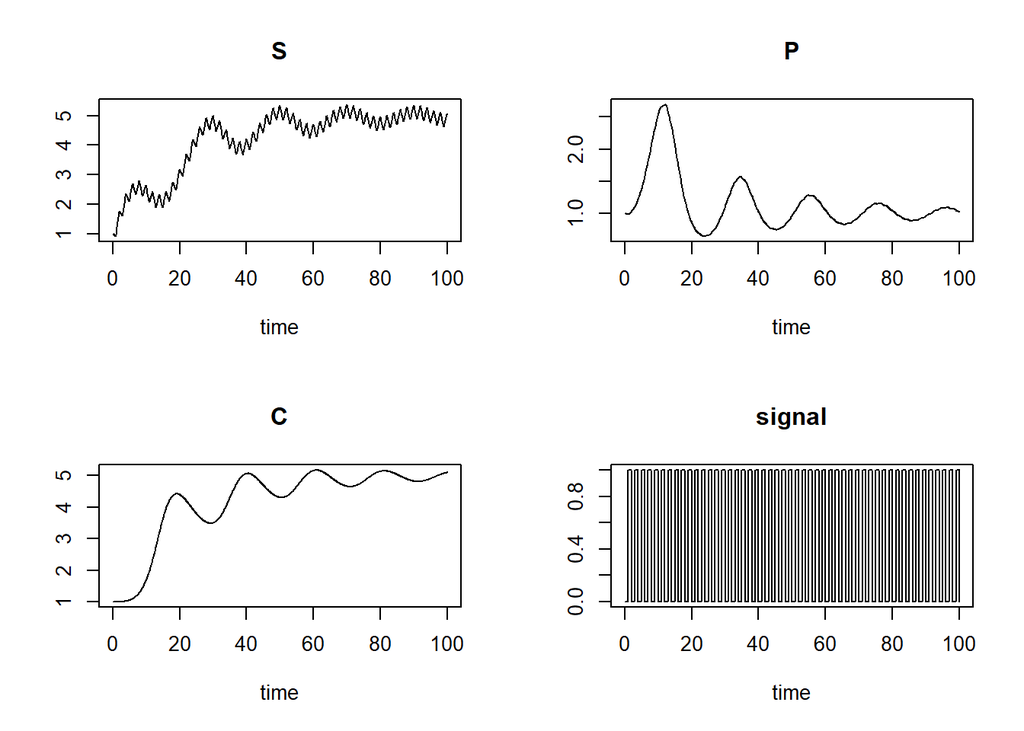

```r
out <- ode(y = xstart, times = times, func = SPCmod, parms)
plot(out)
```

## Events

An event is a discontinuity in a dynamic model, when the values of state variables change abruptly. In most programming environments, events are techically cumbersome, because when an event occurs, the simulation needs to be restarted. This can be done by chaining seperate simulations in loops, but the resulting code can quickly become messy and difficult to read.

The good news is, that package *deSolve** has a built-in event handling mechanism, where events are part of a model, so that no restart will be necessary by the user.

**Two different types of events in R**

The event handling mechanism of **R/deSolve** can handle two different types of events:

1. Events occur at known times
   - Simple changes can be specified in a data.frame with:
     - name of state variable that is affected
     - the time of the event
     - the magnitude of the event
     - event method (“replace,” “add,” “multiply”)
   - More complex events can be specified in an event function that returns the changed values of the state variables `function(t, y, parms, ...)`
2. Events occur when certain conditions are met:
   - Event is triggered by a root function
   - Event is specified in an event function

The details are explained at the `?events` help page, but let us now show a small example.

## Example 2: A patient gets injections in the blood

The example describes is a typical pharmacokinetic problem. The aim is to follow the concentration of the drug in the blood and the tissue of the person over a relatively long time (e.g. hours or days), but the injection takes only a few seconds. One idea to model this would be a time dependent forcing variable for the drug.

This can work, but in most cases it will be very inefficient. The reason is, that the simulation time step of the solver must always be shorter than the time step of an external discrete forcing function. Otherwise, the solver may jump over the the short time periof when the injection occurs. It is obvious that is not very clever to simulate a model with resolution of seconds over several days, just to make sure that a single injection is not overlooked.

Events are a better appraoch for this problem. Then the ODE can be efficiently solved with a (relatively long) automatic time step, and the event mechanism stops it when something important occurs.

**Problem Formulation**

The model consists then of two parts:

1. an ODE model for the dynamics between the events
   - the initial drug concentration is zero
   - if a drug is present, it decays with rate $b$
2. an event for the injection
   - if an injection occurs, the state variable $blood$ is directly changed

**ODE model of 1st order drug decay:**

```r
pharmaco <- function(t, blood, p) {
  dblood <- - b * blood
  list(dblood)
}
b <- 0.6
yini <- c(blood = 0)
```

**The event function**

The events can be specified in an event data.frame, containing the state variable that is to be manipulated (`blood`), the time steps, when the events occur (`time`), the amount of change (`value`) and the method, how the state variable is changed, for example:

- Daily doses, at same time of day
- Injection makes the concentration in the blood increase by 40 units.

```r
injectevents <- data.frame(var = "blood",
                          time = 0:20,
                         value = 40,
                        method = "add")
head(injectevents)
```

```
##     var time value method
## 1 blood    0    40    add
## 2 blood    1    40    add
## 3 blood    2    40    add
## 4 blood    3    40    add
## 5 blood    4    40    add
## 6 blood    5    40    add
```

**Solve the model**

- Pass events to the solver in a list
- All solvers of **deSolve** can handle events
- Here we use the “implicit Adams” method

```r
times <- seq(from = 0, to = 10, by = 1/24)
outDrug <- ode(func = pharmaco, times = times, y = yini,
  parms = NULL, method = "impAdams",
  events = list(data = injectevents))
```

**Plot the result**

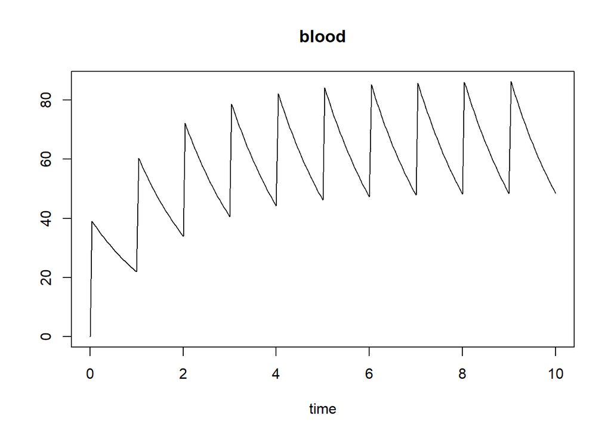

```r
plot(outDrug)
```

## Example 3: An event triggered by a root: A bouncing ball

**Problem formulation**

- A ball is thrown vertically from the ground: $y(0) = 0$
- Initial velocity: $y' = 10 \mathrm m s^{-1}$; acceleration $g = 9.8 \mathrm m s^{-2}$
- When ball hits the ground, it bounces.

**ODEs describe height of the ball above the ground (y)**

The ODEs can be specified as 2nd order ODE, where $y$ ($\mathrm m$) is the height above ground, $y'$ ($\mathrm m s^{-1}$) is the velocity and $y''$ ($\mathrm m s^{-2}$) is the acceleration:

$$\begin{align}
y'' &= -g \\
y(0) &= 0 \\
y'(0) &= 10
\end{align}$$

To solve a 2nd order ODE numerically, it is first transformed to a system of two 1st order ODEs by substituting $y'$ with $y_2$. This forms then the following 1st order ODE:

$$\begin{align}
y_1' &= y_2 \\
y_2' &= -g \\
y1(0) &= 0 \\
y2(0) &= 10
\end{align}$$

**Dynamics inbetween events**

```r
library(deSolve)
ball <- function(t, y, parms) {
  dy1 <- y[2]
  dy2 <- -9.8
  list(c(dy1, dy2))
}
yini <- c(height = 0, velocity = 10)
```

**The Ball hits the ground and bounces**

The root event occurs if the ball hits the ground:

- The ground is where height = 0
- The root function is 0 when $y_1$ = 0

```r
rootfunc <- function(t, y, parms) return (y[1])
```

**Event: the ball bounces**

- The velocity changes its sign (-) and is reduced by 10%
- Event function returns changed values of both state variables

```r
eventfunc <- function(t, y, parms) {
  y[1] <- 0
  y[2] <- -0.9*y[2]
  return(y)
}
```

**Solve the model**

- Inform solver that event is triggered by root (root = TRUE)
- Pass event function to solver
- Pass root function to solver

```r
times <- seq(from = 0, to = 20, by = 0.01)
out <- ode(times = times, y = yini, func = ball,
parms = NULL, rootfun = rootfunc,
events = list(func = eventfunc, root = TRUE))
```

**Get information about the root (hitting the ground)**

```r
attributes(out)$troot
```

```
##  [1]  2.040816  3.877551  5.530612  7.018367  8.357347  9.562428 10.647001
##  [8] 11.623117 12.501621 13.292274 14.003862 14.644290 15.220675 15.739420
## [15] 16.206290 16.626472 17.004635 17.344981 17.651291 17.926970 18.175080
## [22] 18.398378 18.599345 18.780215 18.942998 19.089501 19.221353 19.340019
## [29] 19.446818 19.542936 19.629441 19.707294 19.777362 19.840421 19.897174
## [36] 19.948250 19.994217
```

**Plot results**

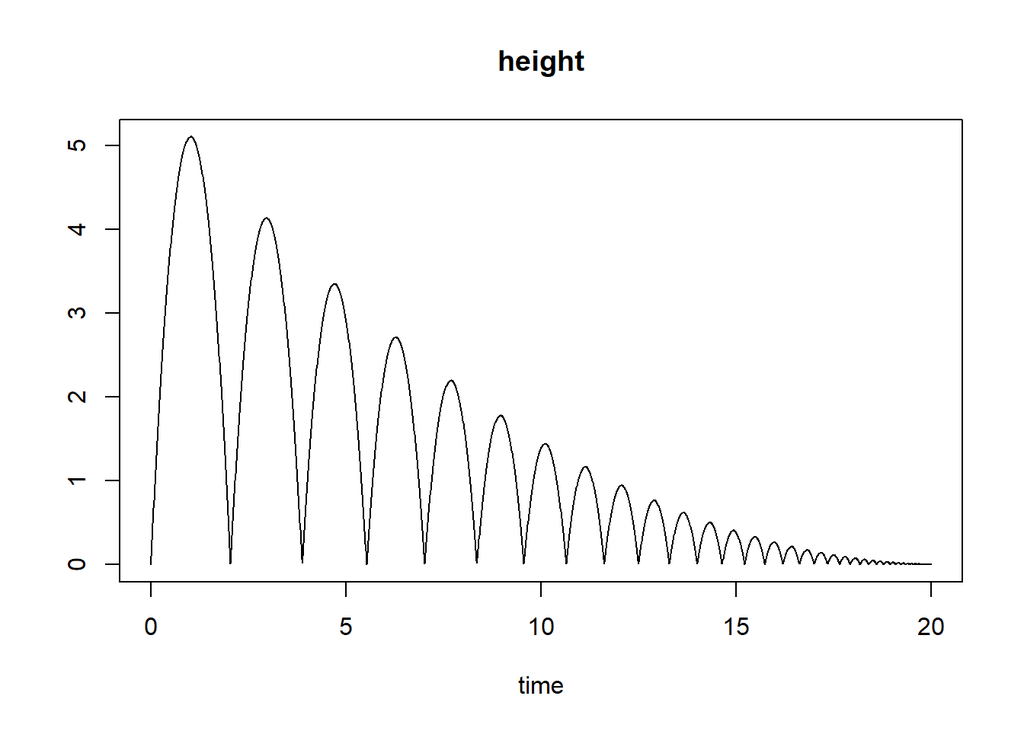

```r
plot(out, select = "height")
```

**Create movie-like output**

```r
for (i in seq(1, 2001, 10)) {
  plot(out, which = "height", type = "l", lwd = 1,
       main = "", xlab = "Time", ylab = "Height"
  )
  points(t(out[i,1:2]), pch = 21, lwd = 1, col = 1, cex = 2,
         bg = rainbow(30, v = 0.6)[20-abs(out[i,3])+1])
  Sys.sleep(0.01)
}
```

## Exercise: Add events to a logistic equation

The logistic equation is a fundamental theoretical and sometimes also practical model, where population growth is described by a population growth rate $r$ and a carrying capacity $K$. It is the origin of the well-known terms “r strategists” and “K strategists.”

**ODE: logistic equation of population growth**

Let’s assume the following logistic equation:

$$y' = r\cdot y \cdot \left(1-\frac{y}{K}\right)$$

with $r=1$, $K=10$ and $y_0=2$

**Events: the population is harvested according to several strategies**

1. No harvesting
2. Every 2 days the population’s density is reduced to 50%
3. When the population approaches 80% of its carrying capacity, its density is halved.

**Tasks**

Use the code fragment below as a template.

**Template**

Copy the template in your favorite editor (e.g. RStudio) and fill the gaps.

```r
## =============================================================================
## Logistic growth with harvesting
## =============================================================================
require(deSolve)

derivs <- function(t, y, parms)
  list(r * y * (1-y/K))

r <- 1
K <- 10
yini <- c(y = 2)
times <- seq(from = 0, to = 20, by = 0.1)

## =============================================================================
# First run: unharvested
## =============================================================================
out1 <- ode(y = yini, times = times, func = derivs, parms = NULL)

## =============================================================================
# Second run: harvest at preset times
## =============================================================================

## ****  Fill in this part:  ******

harvest <- data.frame(
                    var =   , # what is the name of the variable,
                    time =  , # at which times do the events occur,
                    value = , # what is the value
                    method = )# what is the method used ("multiply", "add", ...)

out2 <- ode(y = yini, times = times, func = derivs, parms = NULL,
            events = list(data = harvest))

## =============================================================================
# Third run: harvest when critical density is readhed
## =============================================================================

rootfunc  <- function(t, y, p)
#  **** Fill in this part:   a root is when y = 0.8*K ****
  return( )

eventfunc <- function(t, y, p)
# **** Fill in this part:  variable y is reduced with 50%  ****
  return( )

out3 <- ode(y = yini, times = times, func = derivs, parms = NULL,
            rootfun = rootfunc, events = list(func = eventfunc, root = TRUE))

## =============================================================================
# Plot different scenarios
## =============================================================================

plot(out1, out2, out3, lwd = 2, col = "black")
legend ("bottomright", lwd = 2, lty = 1:3,
    legend = c("unharvested", "2-day harvest", "harvest at 80% of K"))
```

## References

R Core Team. 2018. *R: A Language and Environment for Statistical Computing*. Vienna, Austria: R Foundation for Statistical Computing. https://www.R-project.org/.

Soetaert, Karline, Thomas Petzoldt, and R. Woodrow Setzer. 2010a. “Solving Differential Equations in R.” *The R Journal* 2 (2): 5–15. https://journal.r-project.org/archive/2010-2/RJournal_2010-2_Soetaert~et~al.pdf.

———. 2010b. “Solving Differential Equations in R: Package deSolve.” *Journal of Statistical Software* 33 (9): 1–25. https://doi.org/10.18637/jss.v033.i09.

**Copyright and original author:** tpetzoldt, 2021-07-16